# Wolverine 2022 Modeling Update

Brian D. Gerber and Jacob S. Ivan

2025-08-1

## **Context**

The spatial occupancy model was refit to the 2022 wolverine survey data:

1. There were some organizational changes needed to data input files to make proper comparisons from wolverine occupancy model results from the 2017 and 2022 surveys.
2. Additional surveyed cells in Washington; all non-detections
3. Added the Copeland_Inman habitat covariate on occupancy to make it similar to the model fit to the 2017 survey data.
4. Added bait/lure covariate on detection probability
5. Based on findings from refitting the spatial occupancy model to the 2017 survey data, this model needed to be refit using
   - Used restricted spatial regression (RSR) rather than ICAR
   - More generalized prior probability distribution on the spatial variance parameter.
   - Added an occupancy covariate to separate occurrence probability by mountain range; this allowed CO, UT, and OR to properly estimate an occupancy at / near zero (which makes sense since there were no detections).

## **2022 Survey**

### Summary Information

- The number of sampled cells: 229
- The number of cells in the sampling frame: 770
- The total number of cells with wolverine detections: 44

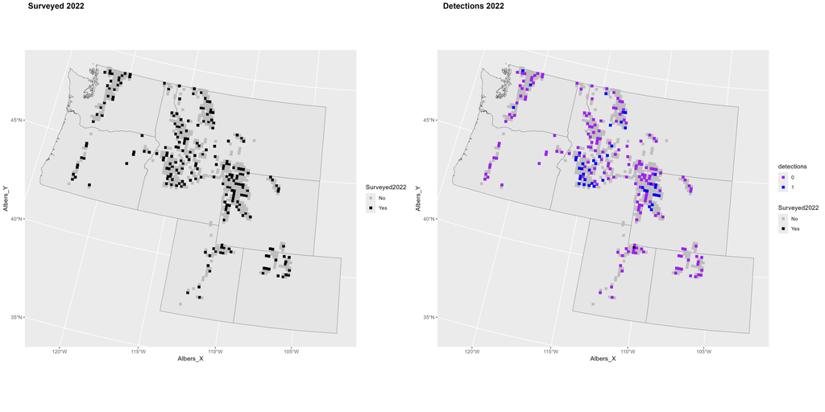

## **Updated Spatial Modeling**

The 2022 wolverine detection / non-detection data were fit using a Bayesian spatial occupancy model (Johnson et al. 2013) via the `stocc` R package.

The spatial process model was fit using restricted spatial regression (RSR) and a threshold of 23,000 m; this forces the spatial process to only affect neighboring cells.

Here is a plot of the occupancy partial intercepts for the different mountain ranges (Grouping1 variable) and slope coefficient for the Copeland_Inman habitat variable; they are all well converged.

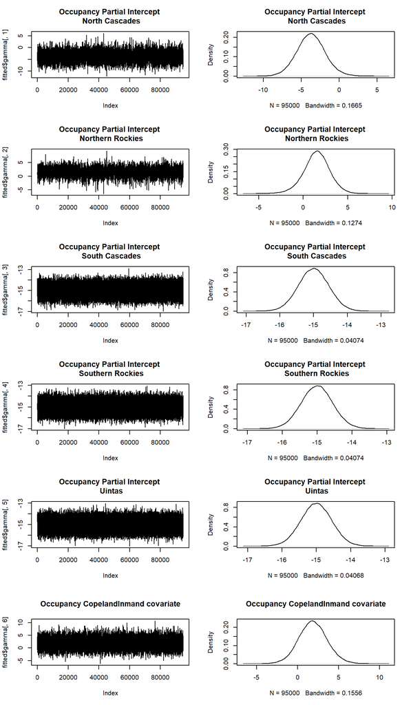

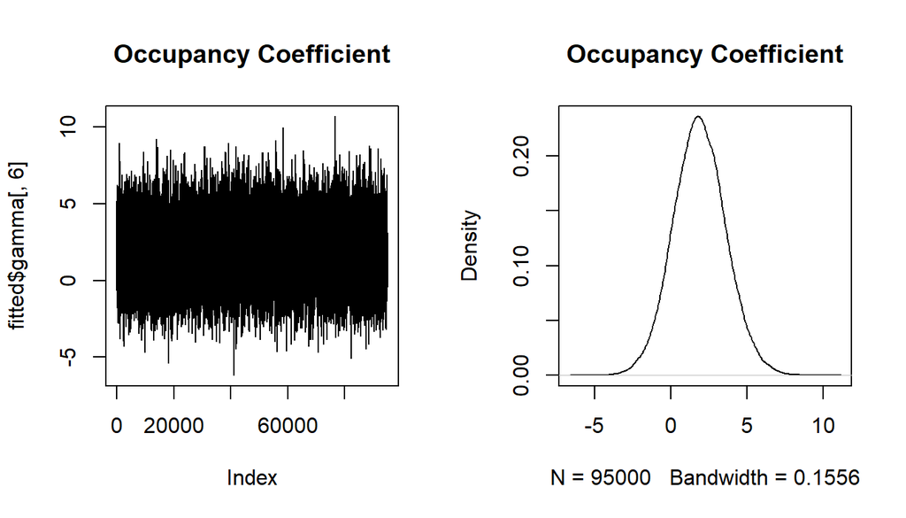

The median and 95% CI’s of the occupancy slope coefficient for the Copeland_Inman habitat variables are

```
##      2.5%       50%     97.5%
## -1.451343  1.863553  5.358882
```

The probability this effect is positive is 0.87

Here is a plot of the spatial variance parameter, well converged and at a realistic value.

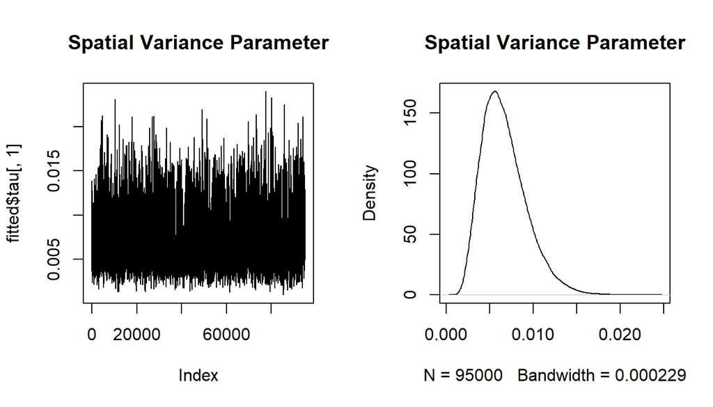

Here is the detection probability parameter.

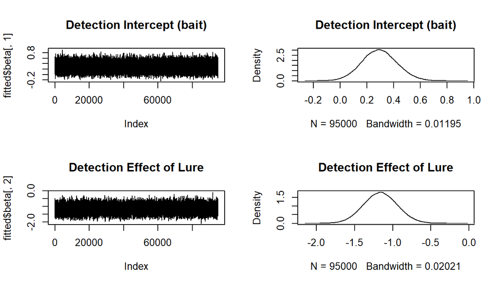

The probability of an effect of lure from bait: 1

The probability of detection for bait and lure:

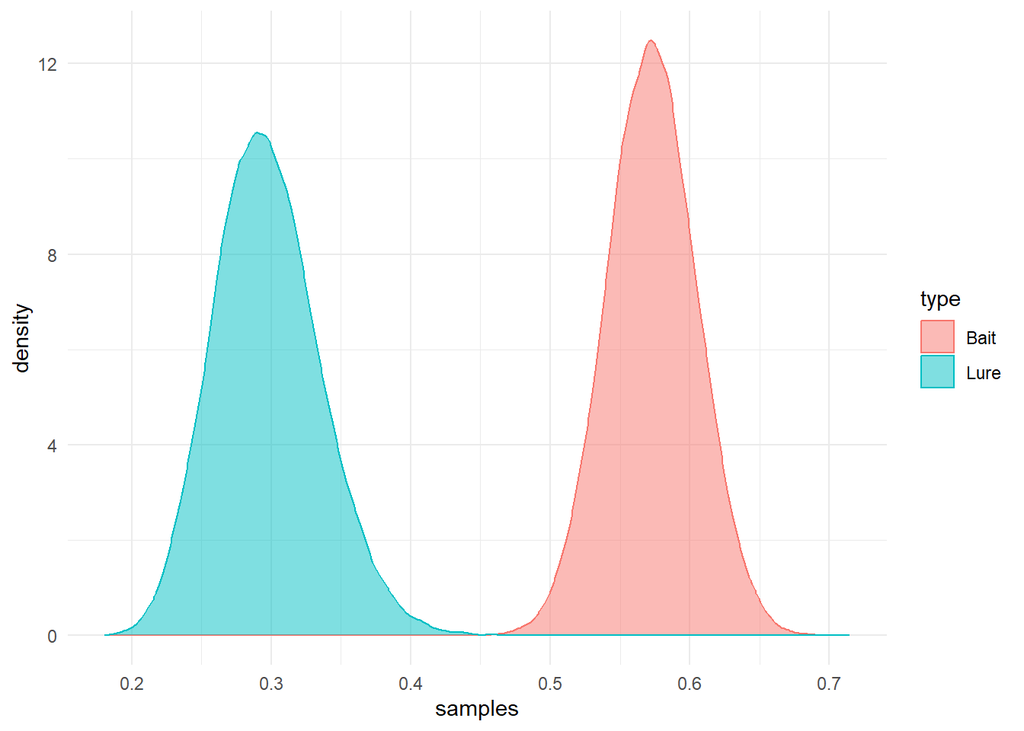

The probability of detecting a wolverine at least once at a site over four one-month occasions:

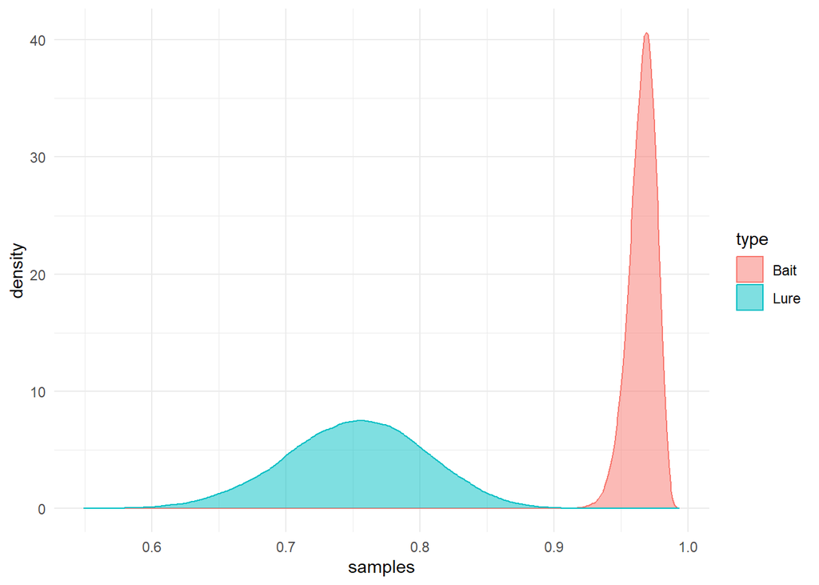

## **Prediction Plots**

### Updated Model Overall Occurence

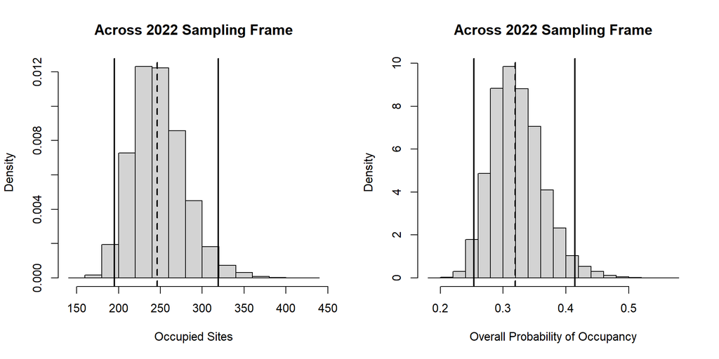

#### *Updated Fitted Model (2022 survey)*

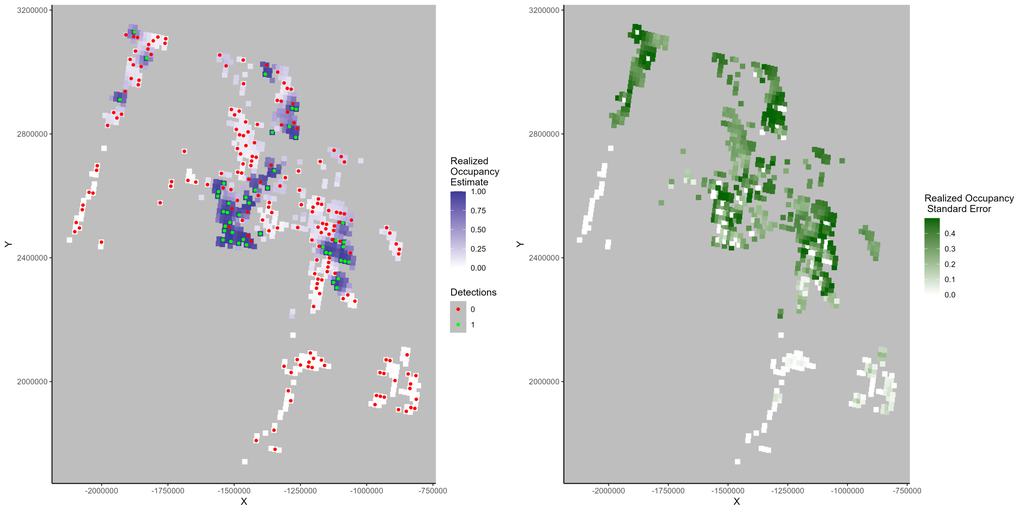

### Updated Fitted model with State Boundaries

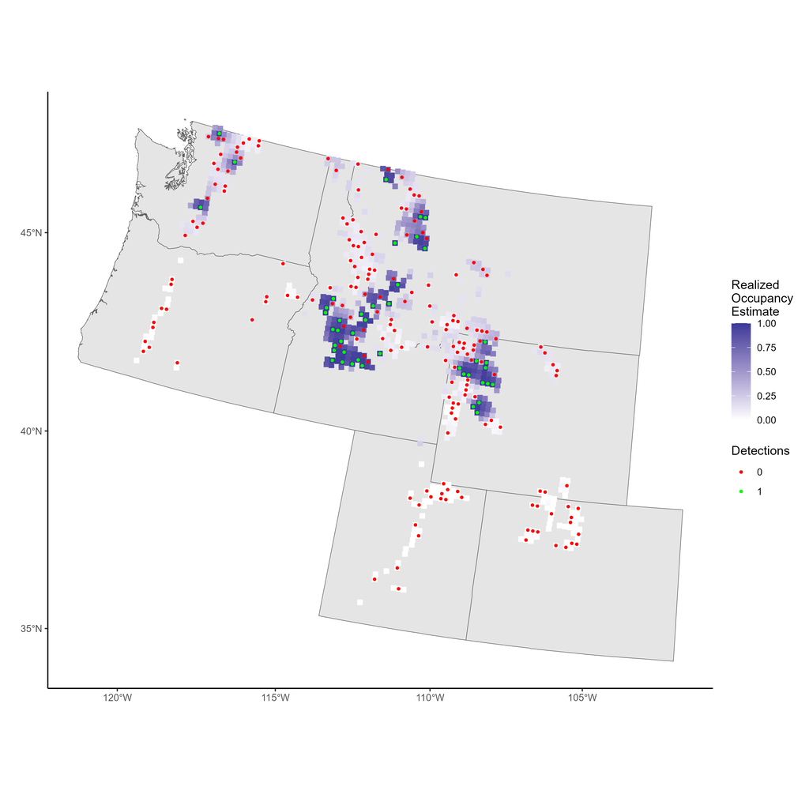

### Updated State Occupancy

Here are the posterior distributions of the number of occupied sites by state (left plot) and the probability a cell is occupied by state (right plot).

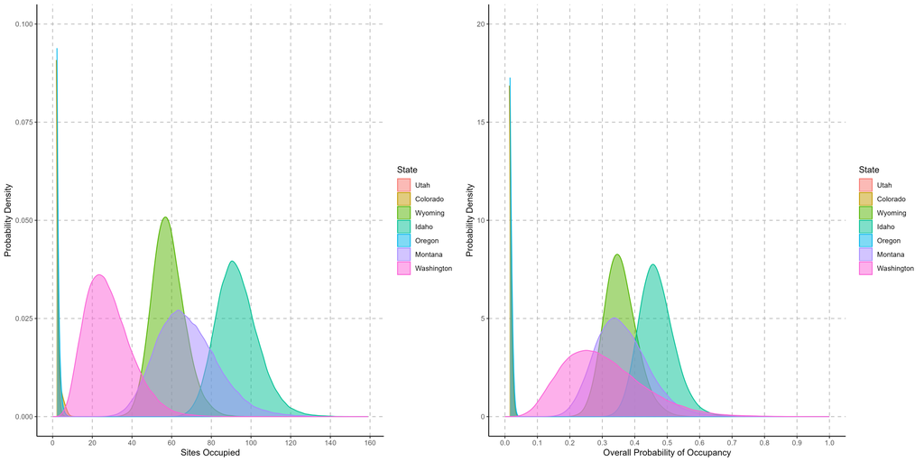

### Number of sites Occupied

| State | X2.5. | X50. | X97.5. |
| --- | --- | --- | --- |
| Utah | 0 | 0 | 1 |
| Colorado | 0 | 0 | 1 |
| Wyoming | 44 | 58 | 76 |
| Idaho | 74 | 92 | 117 |
| Oregon | 0 | 0 | 1 |
| Montana | 42 | 66 | 102 |
| Washington | 10 | 27 | 54 |

### Probability of Occupancy

| State | X2.5. | X50. | X97.5. |
| --- | --- | --- | --- |
| Utah | 0.00 | 0.00 | 0.01 |
| Colorado | 0.00 | 0.00 | 0.01 |
| Wyoming | 0.27 | 0.35 | 0.46 |
| Idaho | 0.37 | 0.46 | 0.59 |
| Oregon | 0.00 | 0.00 | 0.01 |
| Montana | 0.22 | 0.35 | 0.54 |
| Washington | 0.11 | 0.29 | 0.58 |

Johnson, D. S., Conn, P. B., Hooten, M. B., Ray, J. C., & Pond, B. A. (2013). Spatial occupancy models for large data sets. Ecology, 94, 801-808.